# Lab 5: Visualisation in R

Makesh Srinivasan

9/7/2021

Registration number: 19BCE1717  
Faculty: Dr. C. Sweetlin Hemalatha  
Slot: L39 + L40  
Course code: CSE3505

## Questions

1. Plot a bar graph for the number of male and female participants in the survey. Provide the title as “Male and Female participants”, y-axis label as “frequency” and specify the colours for the bars.

```r
library(MASS)
library(dplyr)
data(survey)
newsurvey <- survey

any(duplicated(newsurvey))
```

```
## [1] FALSE
```

```r
any(is.na(newsurvey))
```

```
## [1] TRUE
```

```r
newsurvey <- na.omit(newsurvey)
any(is.na(newsurvey))
```

```
## [1] FALSE
```

```r
df <- newsurvey %>%
  group_by(Sex) %>%
  summarise(total = length(Sex))
df
```

```
## # A tibble: 2 × 2
##   Sex    total
##   <fct>  <int>
## 1 Female    84
## 2 Male      84
```

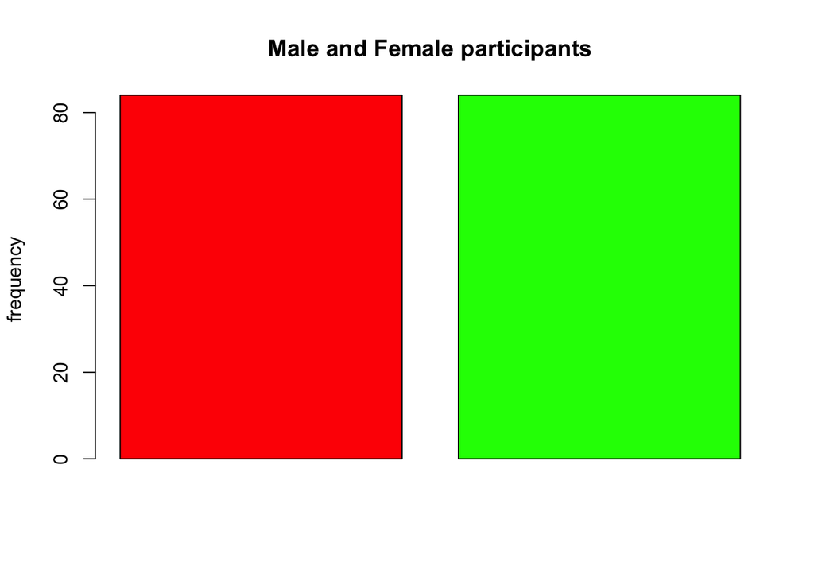

```r
barplot(df$total, main = 'Male and Female participants', ylab = 'frequency', col=c("red", "green"))
```

2. Plot a bar graph for the number of left handers and right handers in the survey. Provide the title as “Left Handers and Right Handers”, y-axis label as “count” and specify the colours for the bars.

```r
df2 <- newsurvey %>%
  group_by(W.Hnd) %>%
  summarise(total = length(W.Hnd))
df2
```

```
## # A tibble: 2 × 2
##   W.Hnd total
##   <fct> <int>
## 1 Left     12
## 2 Right   156
```

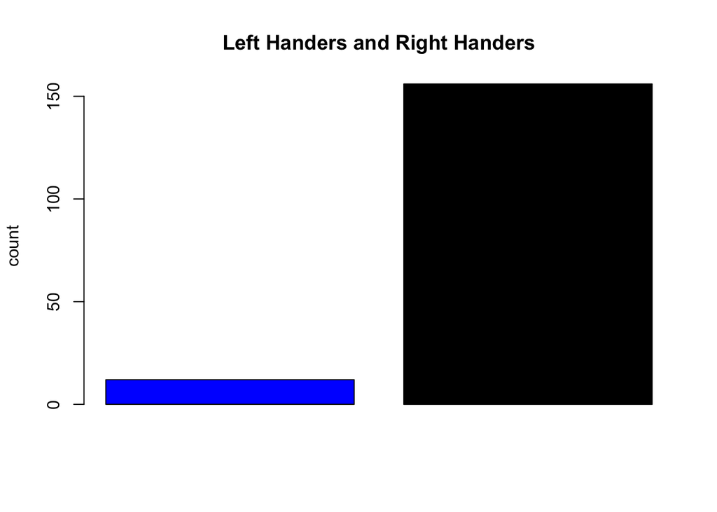

```r
barplot(df2$total, main = 'Left Handers and Right Handers', ylab = 'count', col=c("blue", "black"))
```

3. Plot the distribution between male left handers and female left handers using bar chart. Provide the title as “Female Left Handers and Male Left Handers , y-axis label as “count” and specify the colours for the bars.

```r
df3 <- newsurvey %>%
  filter(W.Hnd=="Left")%>%
  group_by(Sex) %>%
  summarise(total = length(W.Hnd))
df3
```

```
## # A tibble: 2 × 2
##   Sex    total
##   <fct>  <int>
## 1 Female     5
## 2 Male       7
```

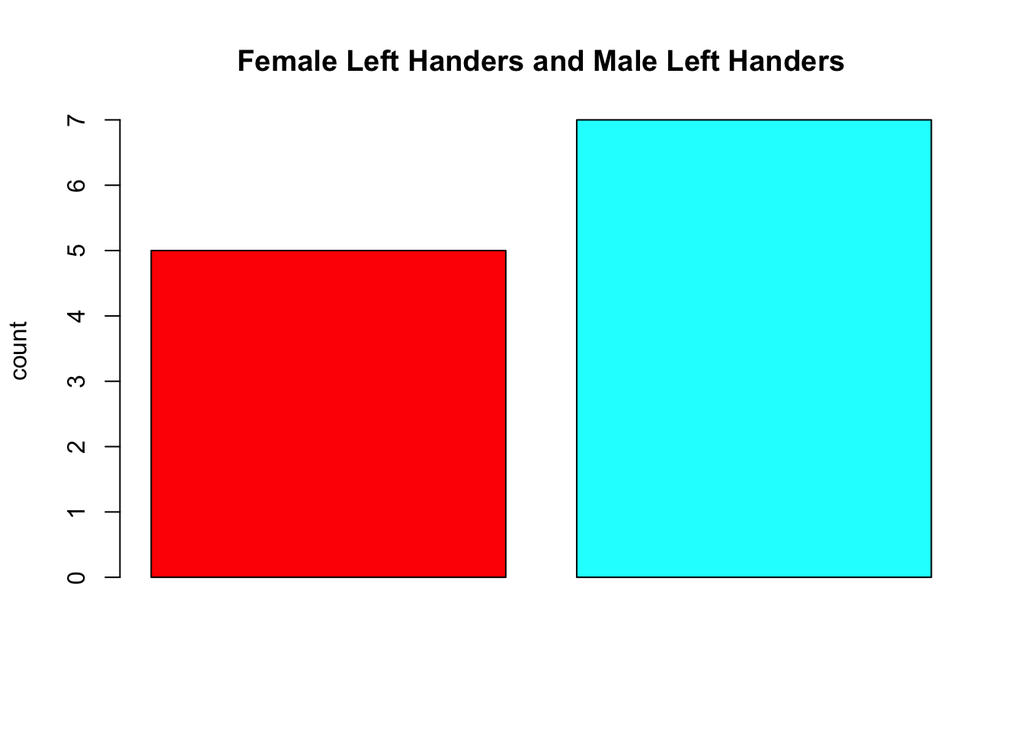

```r
barplot(df3$total, main = 'Female Left Handers and Male Left Handers', ylab = 'count', col=rainbow(2))
```

4. Draw the distribution of smoking habits of male left handers using pie chart.

```r
unique(newsurvey$Smoke)
```

```
## [1] Never Regul Heavy Occas
## Levels: Heavy Never Occas Regul
```

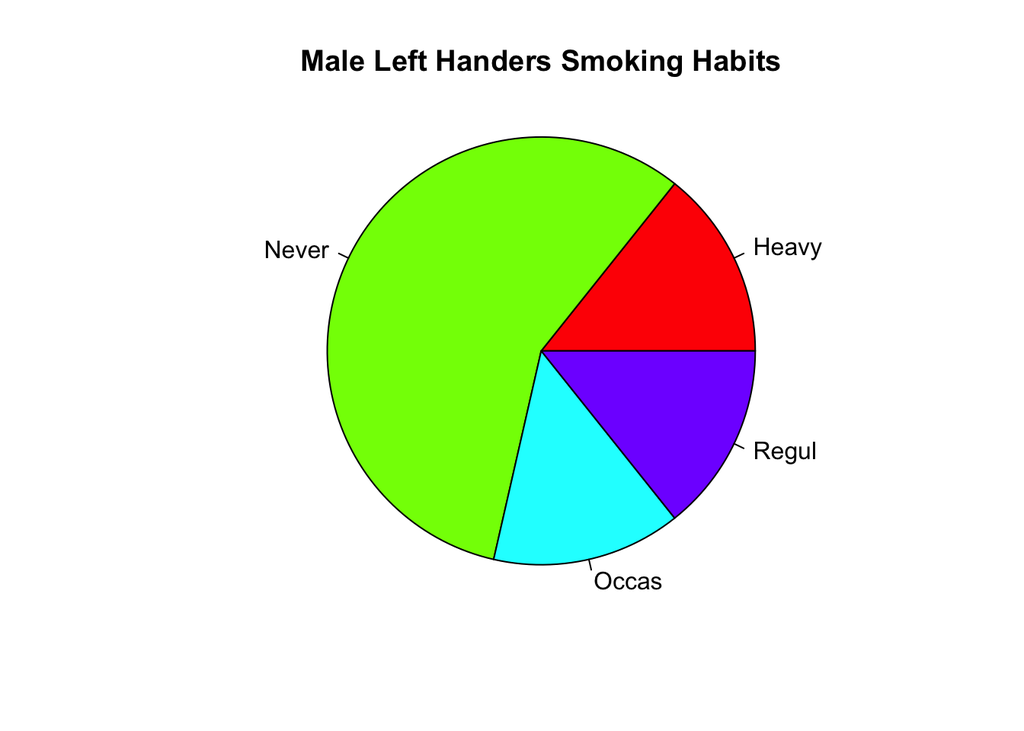

```r
pie(table(newsurvey$Smoke[newsurvey$Sex=="Male"&newsurvey$W.Hnd=="Left"]), main="Male Left Handers Smoking Habits", col=rainbow(length(unique(newsurvey$Smoke))), radius=1)
```

5. Draw the histogram of age distribution with the title as ‘Age distribution’ and xlabel as ‘Age range’ and ylabel as ‘frequency’.

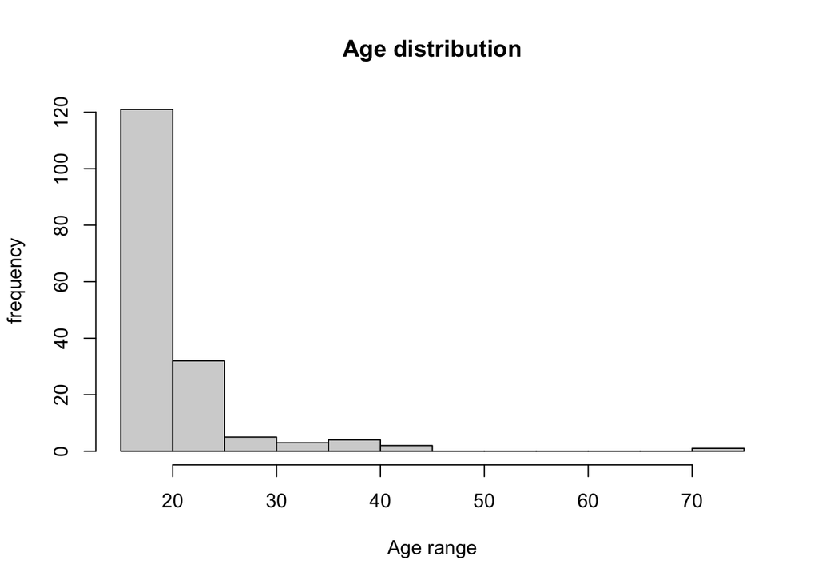

```r
hist(newsurvey$Age, main = "Age distribution", xlab = "Age range", ylab = "frequency")
```

6. Reveal the relationship between the age and writing hand span using scatter plot.

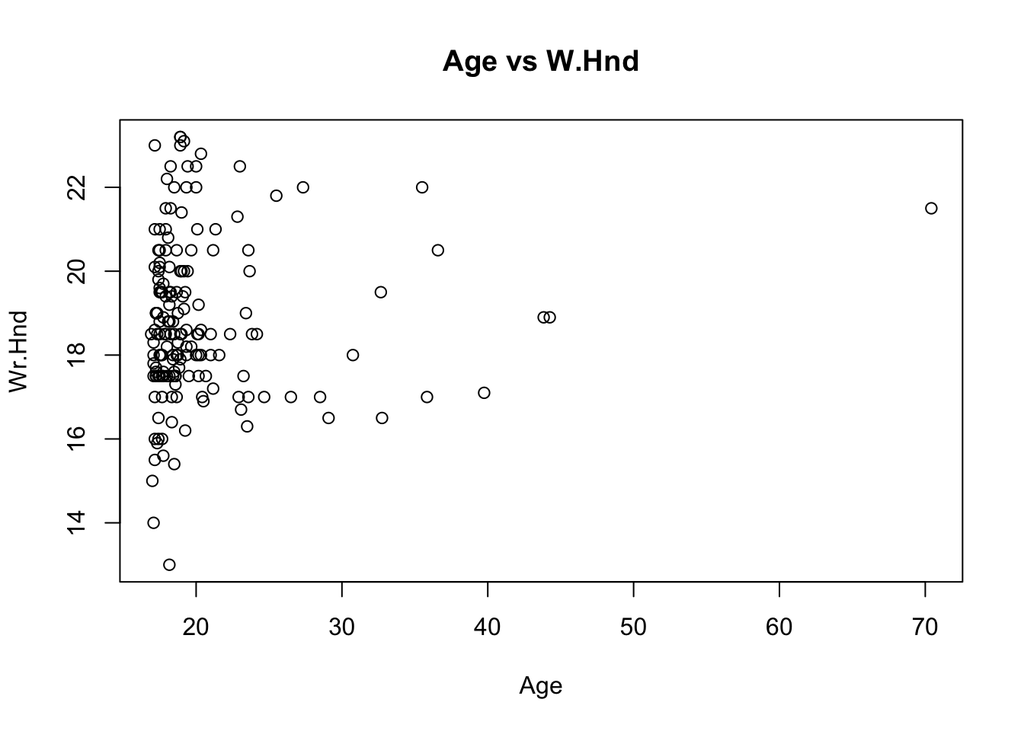

```r
plot(newsurvey$Age,newsurvey$Wr.Hnd, main = "Age vs W.Hnd", xlab = "Age", ylab = "Wr.Hnd")
```

7. Draw the boxplot for pulse rate to analyse the five summary statistics. Provide appropriate title and label.

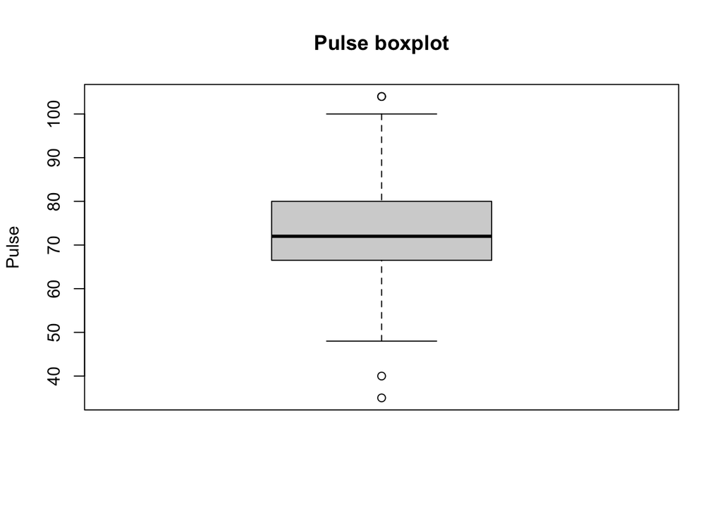

```r
boxplot(newsurvey$Pulse, main="Pulse boxplot", ylab = "Pulse")
```

```r
# There are 3 outliers in the column (Pulse)
```

8. Find if any iris flowers are outliers - meaning any anomolies or mutated flowers in the dataset

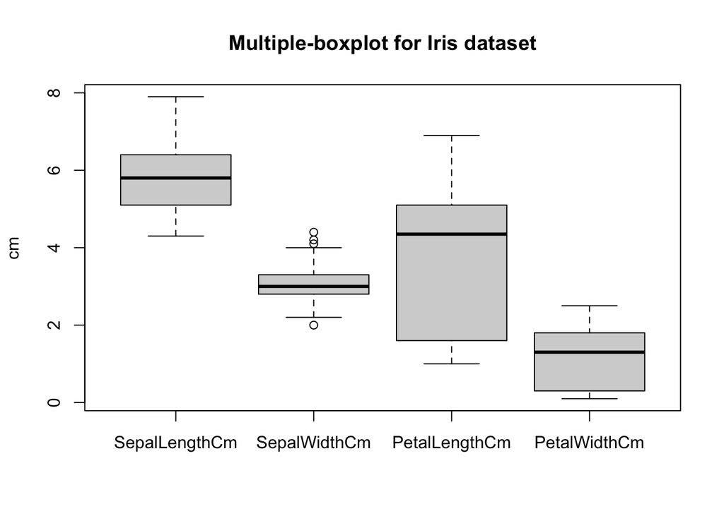

```r
library(lattice)
iris <- read.csv("Iris.csv")
boxplot(iris[, 2:5], main="Multiple-boxplot for Iris dataset", ylab = "cm")
```

```r
# INFERENCE:
# As shown in the box plot, there are no outliers for the columns SepalLengthCm,    PetalLengthCm   and PetalWidthCm
# However, in case of SepalWidthCm, there are four outliers which can be considered as mutated flowers
```

9. Visualize the relationship between petal length and sepal length for each species using a scatter plot

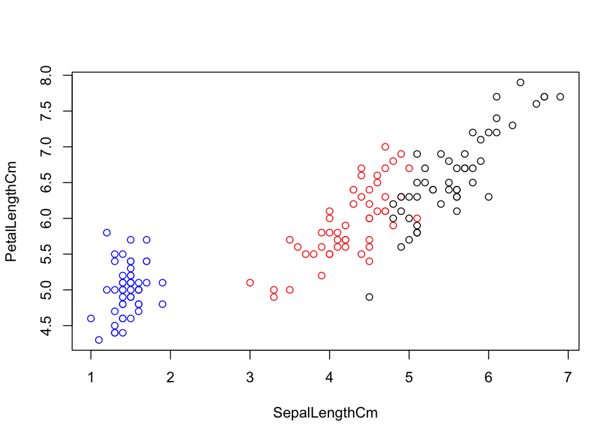

```r
# I used Iris.csv for my lab-4. Thus, I ahve decided to use the same for this exercise.
# The table is already clean and the cleaning process was already explored in the 4th exercise
column <- iris$Species
column[column=="Iris-setosa"]="blue"
column[column=="Iris-virginica"]="black"
column[column=="Iris-versicolor"]="red"
plot(iris$PetalLengthCm, iris$SepalLengthCm, col=column, ylab="PetalLengthCm", xlab="SepalLengthCm")
```

```r
# INFERENCE:
# There is an increasing trend between petal length and sepal length as should be expected
# However, in case of Setosa, the sepal length and petal length are smaller compared to the other two species.

# In the following question, we will see if the size of setosa is in face smaller than the other two using the flower area
```

```r
df10 <- iris%>%
  mutate(area = PetalWidthCm*PetalLengthCm) %>%
  select(Species, area) %>%
  filter(area > 0.7)
df10
```

```
##             Species  area
## 1       Iris-setosa  0.85
## 2       Iris-setosa  0.96
## 3       Iris-setosa  0.76
## 4   Iris-versicolor  6.58
## 5   Iris-versicolor  6.75
## 6   Iris-versicolor  7.35
## 7   Iris-versicolor  5.20
## 8   Iris-versicolor  6.90
## 9   Iris-versicolor  5.85
## 10  Iris-versicolor  7.52
## 11  Iris-versicolor  3.30
## 12  Iris-versicolor  5.98
## 13  Iris-versicolor  5.46
## 14  Iris-versicolor  3.50
```

[output cut: 89 more lines]

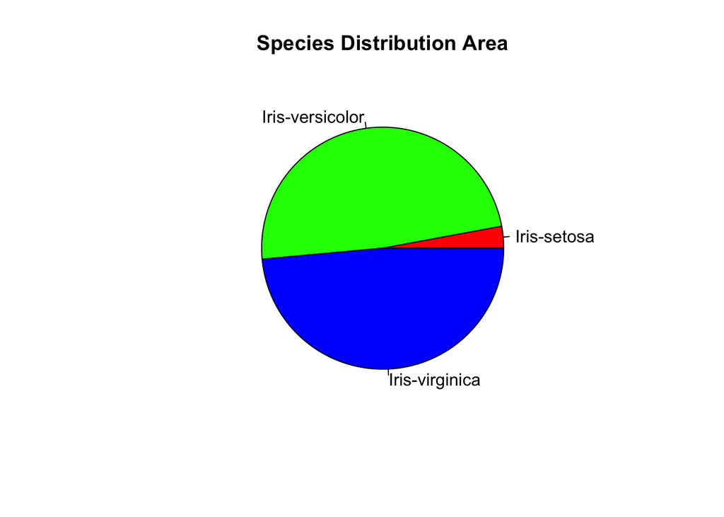

```r
pie(table(df10$Species), col=rainbow(3), main="Species Distribution Area")
```

```r
#INFERENCE:
# This chart suggests that the largest flowers are in the species Iris-versicolor and Iris-virginica and the smallest are the setosa species.
```